# Deep Learning for TS

Author

Haiyu Xiao

This tab will focus on using deep learning models and methods to predict on time series data and extract meaningful results.

```python
import os
import pandas as pd
import numpy as np
import random
import tensorflow as tf
from matplotlib import pyplot as plt
import plotly.io as pio
pio.renderers.default = "plotly_mimetype+notebook_connected"
import plotly.express as px

from keras.models import Sequential
from keras import layers
from keras.optimizers import RMSprop
from keras.layers import Dense, SimpleRNN, LSTM ,GRU
from tensorflow.keras import regularizers

from sklearn.preprocessing import MinMaxScaler
from sklearn.metrics import mean_squared_error
```

## US Wheat Yield Data

First, read the data.

```python
wheat = pd.read_csv("USA_Wheat.csv")
wheat.head()
```

|  | Time | Crop | Yield | Price | Food_Use | Import | Export |
| --- | --- | --- | --- | --- | --- | --- | --- |
| 0 | 8/1/2002 | Wheat | 2.380 | 3.63 | 83,418 | 5,313 | 95,451 |
| 1 | 9/1/2002 | Wheat | 2.380 | 4.21 | 79,583 | 7,235 | 72,242 |
| 2 | 10/1/2002 | Wheat | 2.370 | 4.38 | 80,730 | 5,228 | 78,238 |
| 3 | 11/1/2002 | Wheat | 2.373 | 4.25 | 77,441 | 3,849 | 74,561 |
| 4 | 12/1/2002 | Wheat | 2.370 | 4.06 | 71,306 | 2,558 | 72,920 |

Do some necessary data cleaning, such as extracting needed columns, converting to correct data type, dealing with NaNs, and normalizing.

```python
wheat = wheat.loc[:,["Time","Yield"]]
wheat['Time'] = pd.to_datetime(wheat['Time'])
wheat["Yield"] = wheat["Yield"].fillna(method='ffill')
wheat = wheat.set_index('Time')
wheat = wheat.resample('D').ffill()
```

### Train-Test Split

Performing 80-20 training and testing sets.

```python
scaler = MinMaxScaler(feature_range=(0, 1))
f_wheat = scaler.fit_transform(wheat).flatten()
split = int(len(f_wheat)*0.8)
train = f_wheat[range(split)]
test = f_wheat[split:]

print(train.shape)
print(test.shape)
```

```
(5942,)
(1486,)
```

Plot the train-test-split step:

```python
t1 = [*range(0,len(train))]
t2 = len(train) + np.array([*range(0,len(test))])

fig1 = px.line(x=t1, y=train, title="Wheat Yield in the US", render_mode='SVG')
fig1.add_scatter(x=t1, y=train, mode='lines')
fig1.add_scatter(x=t2, y=test, mode='lines')

fig1.update_layout(
    xaxis_title="Time (Months)",
    yaxis_title="Wheat Production (Hectare/Arce)",
    template="plotly_white",
    showlegend=False
)
# fig1.show(renderer="notebook")
```

[interactive chart not shown]

## RNN

### Reshape Data

In order to perform the keras models, I will first reshape the time series.

```python
def reshape_xy(data, steps):
    global x_index, x, y_index, y

    y_index = np.arange(steps, len(data), steps)
    y = data[y_index]

    x_index = [*range(steps*len(y))]
    del x_index[::steps]
    x = data[x_index]

    x1 = np.reshape(x, (len(y), (steps-1), 1))

    return x1, y

steps=10
train_x, train_y = reshape_xy(train, steps)
test_x, test_y = reshape_xy(test, steps)

print("steps = " + str(steps))
print("shape of train_x = " + str(train_x.shape))
print("shape of train_y = " + str(train_y.shape))
print("shape of test_x = " + str(test_x.shape))
print("shape of test_y = " + str(test_y.shape))
```

```
steps = 10
shape of train_x = (594, 9, 1)
shape of train_y = (594,)
shape of test_x = (148, 9, 1)
shape of test_y = (148,)
```

### Create and Train RNN Model

I will now create the RNN model with regularization. The recurrent hidden units is 3.

```python
rnn_wheat = Sequential()

rnn_wheat.add(SimpleRNN(3,
                        return_sequences=False,
                        recurrent_regularizer=regularizers.L2(1e-2),
                        input_shape=(train_x.shape[1], train_x.shape[2]),
                        activation='tanh')
             )

rnn_wheat.add(layers.Dense(units=1, activation='linear'))

rnn_wheat.compile(loss='MeanSquaredError', optimizer="RMSprop")
rnn_wheat.summary()
```

```
Model: "sequential"
_________________________________________________________________
 Layer (type)                Output Shape              Param #
=================================================================
 simple_rnn (SimpleRNN)      (None, 3)                 15

 dense (Dense)               (None, 1)                 4

=================================================================
Total params: 19
Trainable params: 19
Non-trainable params: 0
_________________________________________________________________
```

```python
random.seed(140)

rnn_history = rnn_wheat.fit(train_x, train_y,
                            epochs = 100,
                            batch_size = int(0.2*train_x.shape[0]),
                            validation_split = 0.2,
                            verbose=0)
```

### Make Predictions and Compute Loss

Then, I can make predictions with the RNN model:

```python
rnn_train_pred = rnn_wheat.predict(train_x).squeeze()
rnn_test_pred = rnn_wheat.predict(test_x).squeeze()
print("train and test prediction shape: " + str(rnn_train_pred.shape) + str(rnn_test_pred.shape))
```

```
train and test prediction shape: (594,)(148,)
```

And compute the RMSE of the predictions:

```python
rnn_train_rmse = np.sqrt(mean_squared_error(rnn_train_pred, train_y))
rnn_test_rmse = np.sqrt(mean_squared_error(rnn_test_pred, test_y))
print("Training RMSE = " + str(rnn_train_rmse))
print("Testing RMSE = " + str(rnn_test_rmse))
```

```
Training RMSE = 0.023797254367979585
Testing RMSE = 0.049004633549479294
```

### Visualizations

Then, I can plot the RMSE along the training epochs:

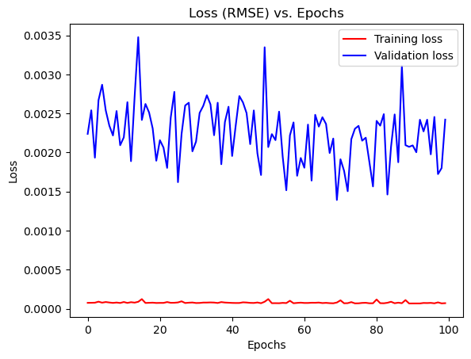

```python
epochs = [*range(0, len(rnn_history.history['loss']))]

plt.figure()
plt.plot(epochs, rnn_history.history['loss'], color='r', label='Training loss')
plt.plot(epochs, rnn_history.history['val_loss'], color='b', label='Validation loss')
plt.title("Loss (RMSE) vs. Epochs")
plt.xlabel("Epochs")
plt.ylabel("Loss")
plt.legend()
```

Next, I will also plot the original and the predictions on the testing time series:

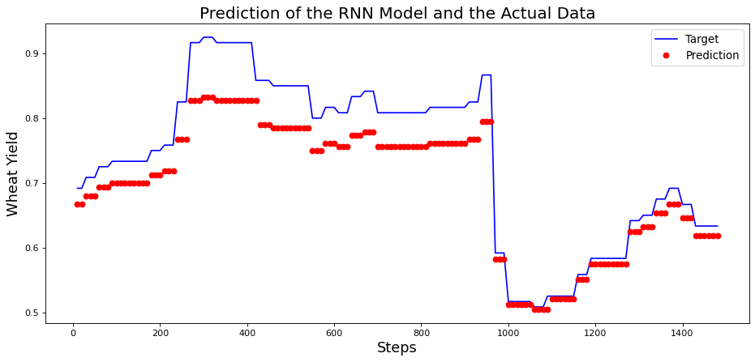

```python
plt.figure(figsize=(14, 6), dpi=80)

plt.plot(y_index, y, 'b-', label='Target')
plt.plot(y_index, rnn_test_pred, 'ro', label='Prediction');
plt.title('Prediction of the RNN Model and the Actual Data', fontsize=18)
plt.xlabel('Steps', fontsize=16)
plt.ylabel('Wheat Yield', fontsize=16)
plt.legend(fontsize=12)
plt.show()
```

Based on the loss plot and the testing series prediction, the RNN model is performing well and made accurate predictions. It is worth noting that there still may be overfitting despite the usage of regularization, since the testing RMSE is larger than the training RMSE. We will compare this performance with other two deep learning models in the next steps.

## GRU

For the GRU model the steps will be similar to the RNN model, also applying regularization.

### Create and Train GRU Model

```python
gru_wheat = Sequential()

gru_wheat.add(GRU(3,
                  return_sequences=False,
                  recurrent_regularizer=regularizers.L2(1e-2),
                  input_shape=(train_x.shape[1], train_x.shape[2]),
                  activation='tanh')
             )

gru_wheat.add(layers.Dense(units=1, activation='linear'))

gru_wheat.compile(loss='MeanSquaredError', optimizer="RMSprop")
gru_wheat.summary()
```

```
Model: "sequential_1"
_________________________________________________________________
 Layer (type)                Output Shape              Param #
=================================================================
 gru (GRU)                   (None, 3)                 54

 dense_1 (Dense)             (None, 1)                 4

=================================================================
Total params: 58
Trainable params: 58
Non-trainable params: 0
_________________________________________________________________
```

```python
random.seed(140)

gru_history = gru_wheat.fit(train_x, train_y,
                            epochs = 100,
                            batch_size = int(0.2*train_x.shape[0]),
                            validation_split = 0.2,
                            verbose=0)
```

### Make Predictions and Compute Loss

```python
gru_train_pred = gru_wheat.predict(train_x).squeeze()
gru_test_pred = gru_wheat.predict(test_x).squeeze()
print("train and test prediction shape: " + str(gru_train_pred.shape) + str(gru_test_pred.shape))
```

```
train and test prediction shape: (594,)(148,)
```

```python
gru_train_rmse = np.sqrt(mean_squared_error(gru_train_pred, train_y))
gru_test_rmse = np.sqrt(mean_squared_error(gru_test_pred, test_y))
print("Training RMSE = " + str(gru_train_rmse))
print("Testing RMSE = " + str(gru_test_rmse))
```

```
Training RMSE = 0.013801783208841407
Testing RMSE = 0.025060942257268102
```

### Visualizations

Again, I will make RMSE vs. Epochs plot and the prediction on the testing time series plot.

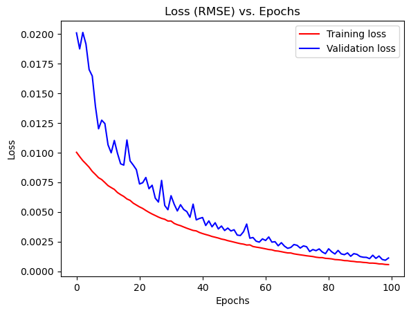

```python
epochs = [*range(0, len(gru_history.history['loss']))]

plt.figure()
plt.plot(epochs, gru_history.history['loss'], color='r', label='Training loss')
plt.plot(epochs, gru_history.history['val_loss'], color='b', label='Validation loss')
plt.title("Loss (RMSE) vs. Epochs")
plt.xlabel("Epochs")
plt.ylabel("Loss")
plt.legend()
```

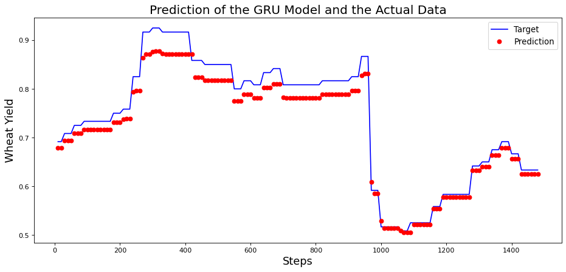

```python
plt.figure(figsize=(14, 6), dpi=80)

plt.plot(y_index, y, 'b-', label='Target')
plt.plot(y_index, gru_test_pred, 'ro', label='Prediction');
plt.title('Prediction of the GRU Model and the Actual Data', fontsize=18)
plt.xlabel('Steps', fontsize=16)
plt.ylabel('Wheat Yield', fontsize=16)
plt.legend(fontsize=12)
plt.show()
```

GRU model has smaller training and testing RMSE than the RNN model, and the plot of the testing and predicted time series here closer but still similar to the RNN model, meaning that these two models make almost identical predictions on the testing data. Therefore, RNN and GRU model are both successful for now.

## LSTM

### Create and Train LSTM Model

```python
lstm_wheat = Sequential()

lstm_wheat.add(LSTM(3,
                    return_sequences=False,
                    recurrent_regularizer=regularizers.L2(1e-2),
                    input_shape=(train_x.shape[1], train_x.shape[2]),
                    activation='tanh')
             )

lstm_wheat.add(layers.Dense(units=1, activation='linear'))

lstm_wheat.compile(loss='MeanSquaredError', optimizer="RMSprop")
lstm_wheat.summary()
```

```
Model: "sequential_2"
_________________________________________________________________
 Layer (type)                Output Shape              Param #
=================================================================
 lstm (LSTM)                 (None, 3)                 60

 dense_2 (Dense)             (None, 1)                 4

=================================================================
Total params: 64
Trainable params: 64
Non-trainable params: 0
_________________________________________________________________
```

I will perform the training process of the LSTM model using the same parameters (recurrent hidden units, epoch size, fraction batch size, validation split.)

```python
random.seed(140)

lstm_history = lstm_wheat.fit(train_x, train_y,
                              epochs = 100,
                              batch_size = int(0.2*train_x.shape[0]),
                              validation_split = 0.2,
                              verbose=0)
```

### Make Predictions and Compute Loss

```python
lstm_train_pred = lstm_wheat.predict(train_x).squeeze()
lstm_test_pred = lstm_wheat.predict(test_x).squeeze()
print("train and test prediction shape: " + str(lstm_train_pred.shape) + str(lstm_test_pred.shape))
```

```
train and test prediction shape: (594,)(148,)
```

```python
lstm_train_rmse = np.sqrt(mean_squared_error(lstm_train_pred, train_y))
lstm_test_rmse = np.sqrt(mean_squared_error(lstm_test_pred, test_y))
print("Training RMSE = " + str(lstm_train_rmse))
print("Testing RMSE = " + str(lstm_test_rmse))
```

```
Training RMSE = 0.0445636255944284
Testing RMSE = 0.09661319785561863
```

### Visualizations

Again, I will first make RMSE vs. Epochs plot, and then the prediction on the testing time series plot.

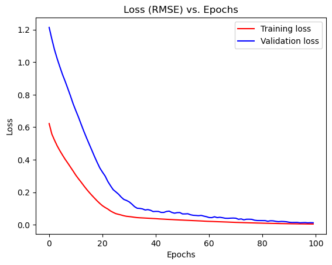

```python
epochs = [*range(0, len(lstm_history.history['loss']))]

plt.figure()
plt.plot(epochs, lstm_history.history['loss'], color='r', label='Training loss')
plt.plot(epochs, lstm_history.history['val_loss'], color='b', label='Validation loss')
plt.title("Loss (RMSE) vs. Epochs")
plt.xlabel("Epochs")
plt.ylabel("Loss")
plt.legend()
```

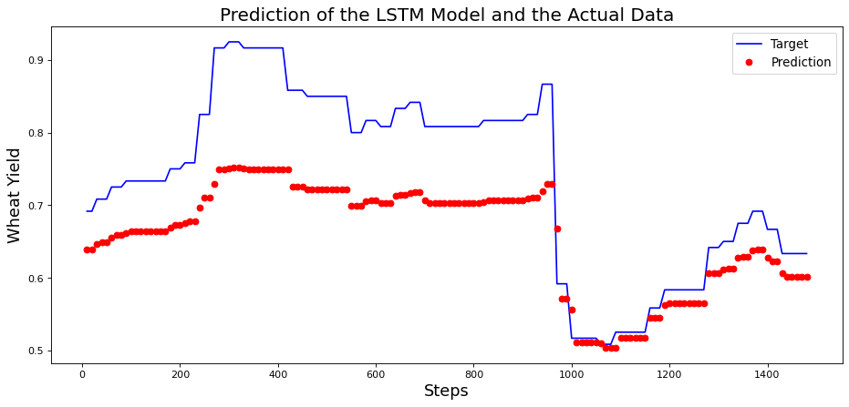

```python
plt.figure(figsize=(14, 6), dpi=80)

plt.plot(y_index, y, 'b-', label='Target')
plt.plot(y_index, lstm_test_pred, 'ro', label='Prediction');
plt.title('Prediction of the LSTM Model and the Actual Data', fontsize=18)
plt.xlabel('Steps', fontsize=16)
plt.ylabel('Wheat Yield', fontsize=16)
plt.legend(fontsize=12)
plt.show()
```

## Comparison between the Models

In order to fully compare the three ANN models with each other in terms of accuracy and predictive power, I will use a table to show the training and testing RMSE of three models, as well as their predictions on the testing time series.

```python
rmse_scores = pd.DataFrame(data={'Model': ['RNN', 'GRU', 'LSTM'],
                                 'Train_RMSE': [rnn_train_rmse, gru_train_rmse, lstm_train_rmse],
                                 'Test_RMSE': [rnn_test_rmse, gru_test_rmse, lstm_test_rmse]})
rmse_scores
```

|  | Model | Train_RMSE | Test_RMSE |
| --- | --- | --- | --- |
| 0 | RNN | 0.023797 | 0.049005 |
| 1 | GRU | 0.013802 | 0.025061 |
| 2 | LSTM | 0.044564 | 0.096613 |

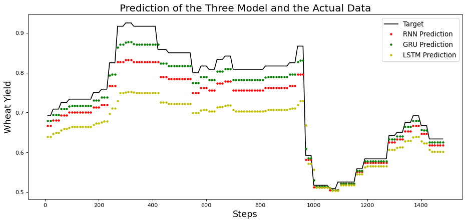

```python
plt.figure(figsize=(14, 6), dpi=80)

plt.plot(y_index, y, 'k-', label='Target')
plt.plot(y_index, rnn_test_pred, 'r.', label='RNN Prediction')
plt.plot(y_index, gru_test_pred, 'g.', label='GRU Prediction')
plt.plot(y_index, lstm_test_pred, 'y.', label='LSTM Prediction')
plt.title('Prediction of the Three Model and the Actual Data', fontsize=18)
plt.xlabel('Steps', fontsize=16)
plt.ylabel('Wheat Yield', fontsize=16)
plt.legend(fontsize=12)
plt.show()
```

First of all, RNN and GRU models have relatively small training and testing RMSE, therefore they are all successful on the wheat yeild dataset. THe LSTM model has larger RMSEs, and is relatively not as accurate as the other two models. The GRU model performs the best, with RNN closely follows, and the plot shows that they have very similar predictions. The prediction of the LSTM model is further from the target at some steps, but the performance is still impressive. And since the testing time series starts at 2018 and ends at 2022, the deep learning models can accurately predict at least 4 years in the future, having about 17 years as training data.

[figure not shown]

It is obvious that including regularization has a significant effect on the results, especially that it minimizes the loss function and prevents overfitting or underfitting. However it is still worth noting that for all the models the testing RMSE is much larger than the training RMSE, indicating that there still may be overfitting problems in the model fittings.

## Compare to ARIMA

To compare the performance of the deep learning models and the ARIMA model I fitted before, I will implement the same ARIMA model, ARIMA(1,1,0), here with the training and testing data. RMSE will be used to examine the performances.

```python
from statsmodels.tsa.arima.model import ARIMA
model_arima = ARIMA(train, order=(1,1,0))
arima_fit = model_arima.fit()
arima_output = arima_fit.forecast(steps=test.shape[0])
```

```python
arima_test_rmse = np.sqrt(mean_squared_error(arima_output, test))
```

```python
rmse_scores1 = pd.DataFrame(data={'Model': ['RNN', 'GRU', 'LSTM', 'ARIMA'],
                                 'Test_RMSE': [rnn_test_rmse, gru_test_rmse, lstm_test_rmse, arima_test_rmse]})
rmse_scores1
```

|  | Model | Test_RMSE |
| --- | --- | --- |
| 0 | RNN | 0.049005 |
| 1 | GRU | 0.025061 |
| 2 | LSTM | 0.096613 |
| 3 | ARIMA | 0.132095 |

We can see that the prediction RMSE of ARIMA(1,1,0) is larger than all the deep learning methods, and except for the LSTM model the other two models have much smaller RMSE. Therefore, RNN and GRU have large advantage over the ARIMA model in terms of forecasting the wheat yield.